# AtlasVPM: Atlas de Farmacia

Variaciones en el consumo de **Antibióticos** por Zona Básica de Salud

Autor/a

Afiliaciones

[Atlas de Variaciones injustificadas de la Práctica Médica (Atlas VPM)](https://cienciadedatosysalud.org/)

Grupo de Ciencia de datos para la investigación en servicios y políticas sanitarias

Instituto Aragonés de Ciencias de la Salud (IACS)

Red de Investigación en Cronicidad, Atención Primaria y Prevención y Promoción de la Salud (RICAPPS)

Fecha de publicación

24 de noviembre de 2026

Versión de los análisis: 0.0.5

# Resumen ejecutivo

El número de envases de antibióticos dispensados en el periodo 2017-2024 aumentó un 18,5% (de 8,7 millones a 10,3 millones de dispensaciones (Región de Murcia no presenta datos para 2017)). El 60,6% de todas estas dispensaciones se realizaron en mujeres. El porcentaje de mujeres con alguna dispensación de antibióticos fue mayor en todos los tramos etarios exceptuando a la población pediátrica. Las tarjetas sanitarias sin aseguramiento, farmacia gratuita y pensionistas y activos con rentas inferiores a 18000 euros (65,6% de la población en las CCAA analizadas) recibieron más del 72,2% de los envases dispensados de antibióticos.

Con variación en la evolución anual y entre CCAA, en torno al 45% de los envases dispensados correspondieron a penicilinas, el 19% a macrólidos, el 14% a otros antibacterianos, el 12% a fluoroquinolonas y cerca del 10% a otros betalactámicos.

La mediana de consumo de antibióticos seleccionados en términos de DHD aumentó ligeramente para el conjunto de ZBS pasando de 14,12 DHD en 2017 a 14,66 DHD en 2024. Con variaciones entre las CCAA analizadas, analizando por subgrupos, se produjo un descenso en penicilinas, y fluoroquinolonas, mientras que el consumo de otros betalactámicos, macrólidos y otros antibacterianos aumentó sensiblemente.

Para el conjunto de antibióticos analizados y años, la variación de DHD entre las ZBS de más y menos consumo, sin considerar las ZBS con valores extremos, fue de una razón de variación de 3 veces las DHD entre estas ZBS, siendo esta variación constante a lo largo de los años. Por subgrupos terapéuticos, esta variación fue más elevada, siendo mayor en macrólidos con una razón de variación de 5,7 veces entre las ZBS de más y menos consumo, otros betalactámicos con una razón de 5,2, fluoroquinolonas con una razón de 4, penicilinas con una razón de variación de 3 y otros antibacterianos con una razón de 2,8.

Para el total de antibióticos, el consumo y variación de DHD fue mayor en el conjunto de TSI < 18000 euros, con una diferencia global del 23,5% en la mediana de consumo.

Respecto a los indicadores del Programa de Resistencia de Antibióticos (PROA), hubo una tendencia estable con cierta distorsión en los valores de los años pandémicos 2020 y 2021. Para el indicador de amoxicilina sin ácido clavulánico (reespecto al total de amoxicilina) el porcentaje de envases dispensados pasó de 51,9% en 2017 a 53% en 2024, en antibióticos de espectro reducido (respecto al total de antibióticos) de 35,2% a 36,3%, en macrólidos (respecto al total de antibióticos) de 17,7% a 19,4%. Sin embargo, en flouroquinolonas (respecto al total de antibióticos) se observa una tendencia decreciente del porcentaje, pasando de 14,1% a 9,9%.

# Contexto

Este informe pertenece a la serie de informes de AtlasVPM sobre Farmacia, en el que se incluyen el análisis de consumo de Opioides y de Antibióticos. En este informe nos referimos a consumo como la dispensación ambulatoria de un fármaco en oficina de farmacia a una persona con tarjeta sanitaria en el Sistema Nacional de Salud (SNS). El consumo de los medicamentos está mediado por la prescripción de un profesional sanitario -principalmente los médicos especialistas en medicina familiar y comunitaria- y, en el caso de algunos medicamentos, al visado de la receta médica por un inspector del SNS. La utilización de los medicamentos, como sucede con otras tecnologías sanitarias, está sujeta a una gran variabilidad. El análisis de las *variaciones en la práctica médica*, entendidas como las variaciones sistemáticas -no aleatorias- en las tasas estandarizadas de una exposición o intervención sanitaria (i.e., consumo de medicamento) al nivel que se produce la toma de decisiones sobre esta exposición o intervención sanitaria, en este caso, a nivel de Zona Básica de Salud (ZBS), es indispensable para identificar potenciales problemas de gestión sanitaria y ayudar a orientar la toma de decisiones sobre los servicios de salud. Las variaciones sistemáticas en los patrones de dispensación de medicamentos antibióticos y opioides suponen un desafío importante para todos los Sistemas de Salud.

**Atención**

Debe tenerse en cuenta que, cuando se habla de grupos mayores (J01C, J01D, J01F, J01MA, J01X) o total (J01) de Antibióticos en este estudio, estos ATC no incluyen todos los antibióticos o antimicrobianos sino sólo aquellos seleccionados como relevantes para estudio que aparecen en Sección 4.3 (para más información descargar el fichero ([Modelo de datos](https://github.com/cienciadedatosysalud/atlas-farmacia/blob/main/atlas_antibioticos/docs/CDM/common_datamodel.xlsx))

# Resultados

En este estudio participan un total de 9 comunidades autónomas, con una población global de 18,472,811 en el año 2024, de la cual, la media mensual de personas distintas que han sido dispensadas de algún antibiótico (ATC = J01) durante el periodo de estudio 2017 a 2024 es de un 3.65%.

**Descripción tabla**

La siguiente tabla muestra el número de envases totales por año, la aportación al mismo por cada comunidad autónoma, sexo y para el conjunto específico de categorías TSI (0,1,2, y 4).

Tabla descriptiva anual: Nº envases (%)

Antibióticos (J01)

|  | 2017 | 2018 | 2019 | 2020 | 2021 | 2022 | 2023 | 2024 |
| --- | --- | --- | --- | --- | --- | --- | --- | --- |
| Total Nº envases anual |  |  |  |  |  |  |  |  |
| Nº envases | 8727949 | 9850978 | 9498197 | 7290345 | 7096644 | 8969975 | 9906988 | 10338597 |
| CCAA |  |  |  |  |  |  |  |  |
| Asturias | 656015 (7.52%) | 639072 (6.49%) | 629821 (6.63%) | 481245 (6.6%) | 482398 (6.8%) | 599366 (6.68%) | 706180 (7.13%) | 735508 (7.11%) |
| País Vasco | 1215863 (13.93%) | 1286945 (13.06%) | 1247146 (13.13%) | 979954 (13.44%) | 940354 (13.25%) | 1147355 (12.79%) | 1272081 (12.84%) | 1356161 (13.12%) |
| Navarra | 317798 (3.64%) | 339618 (3.45%) | 322408 (3.39%) | 236021 (3.24%) | 226904 (3.2%) | 318978 (3.56%) | 359721 (3.63%) | 382993 (3.7%) |
| La Rioja | 133267 (1.53%) | 147081 (1.49%) | 143184 (1.51%) | 114363 (1.57%) | 105886 (1.49%) | 133621 (1.49%) | 137321 (1.39%) | 133783 (1.29%) |
| Aragón | 697982 (8%) | 714492 (7.25%) | 653285 (6.88%) | 527737 (7.24%) | 561470 (7.91%) | 662812 (7.39%) | 663332 (6.7%) | 648351 (6.27%) |
| Madrid | 2787851 (31.94%) | 2707107 (27.48%) | 2643724 (27.83%) | 1968213 (27%) | 1856083 (26.15%) | 2314996 (25.81%) | 2598144 (26.23%) | 2744421 (26.55%) |
| Castilla y León | 1774359 (20.33%) | 1730246 (17.56%) | 1637504 (17.24%) | 1252375 (17.18%) | 1195660 (16.85%) | 1556608 (17.35%) | 1677446 (16.93%) | 1744859 (16.88%) |
| Canarias | 1144814 (13.12%) | 1209513 (12.28%) | 1202010 (12.66%) | 948855 (13.02%) | 979750 (13.81%) | 1240182 (13.83%) | 1340058 (13.53%) | 1381318 (13.36%) |
| Región de Murcia | NA | 1076904 (10.93%) | 1019115 (10.73%) | 781582 (10.72%) | 748139 (10.54%) | 996057 (11.1%) | 1152705 (11.64%) | 1211203 (11.72%) |
| Sexo |  |  |  |  |  |  |  |  |
| Hombres | 3526086 (40.4%) | 3951344 (40.11%) | 3781779 (39.82%) | 2830184 (38.82%) | 2708579 (38.17%) | 3486684 (38.87%) | 3881720 (39.18%) | 4045612 (39.13%) |
| Mujeres | 5201863 (59.6%) | 5899634 (59.89%) | 5716418 (60.18%) | 4460161 (61.18%) | 4388065 (61.83%) | 5483291 (61.13%) | 6025268 (60.82%) | 6292985 (60.87%) |
| Conjunto categorías TSI < 18.000 € (Categorías 0, 1, 2, 4) |  |  |  |  |  |  |  |  |
| Conjunto categorías TSI < 18.000 € (Categorías 0, 1, 2, 4) | 6414887 (73.5%) | 7335885 (74.47%) | 7160039 (75.38%) | 5379197 (73.79%) | 5204675 (73.34%) | 6441248 (71.81%) | 6869728 (69.34%) | 6952152 (67.24%) |

## Porcentaje de envases dispensados por subgrupo terapéutico

**Descripción figura**

Para el total de envases dispensados (suma de todas las comunidades autónomas participantes) en toda la serie temporal, se muestra el porcentaje de envases por cada subgrupo terapéutico.

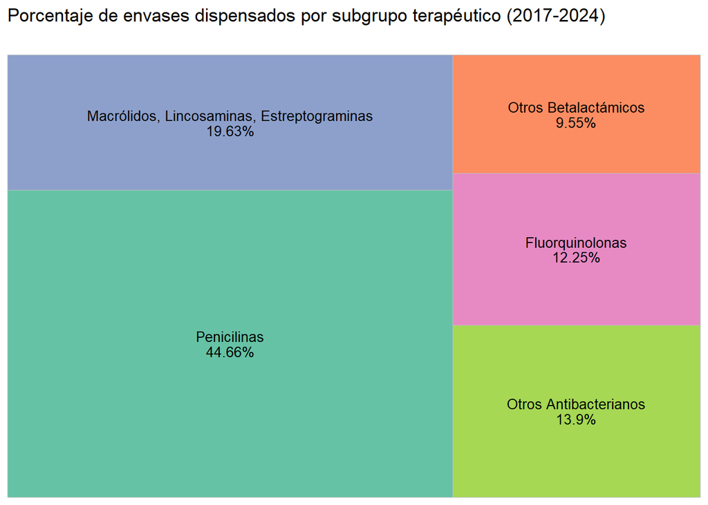

## Evolución temporal del porcentaje de envases dispensados por subgrupo terapéutico

**Descripción figura**

Para el total de envases dispensados en toda la serie temporal en cada comunidad autónoma, se muestra el porcentaje de envases por cada subgrupo terapéutico.

La leyenda es, de acuerdo con la figura anterior,:

- Penicilinas (J01C),
- Otros Betalactámicos (J01D),
- Macrólidos, Lincosaminas, Estreptograminas (J01F),
- Fluorquinolonas (J01MA),
- Otros Antibacterianos (J01X),

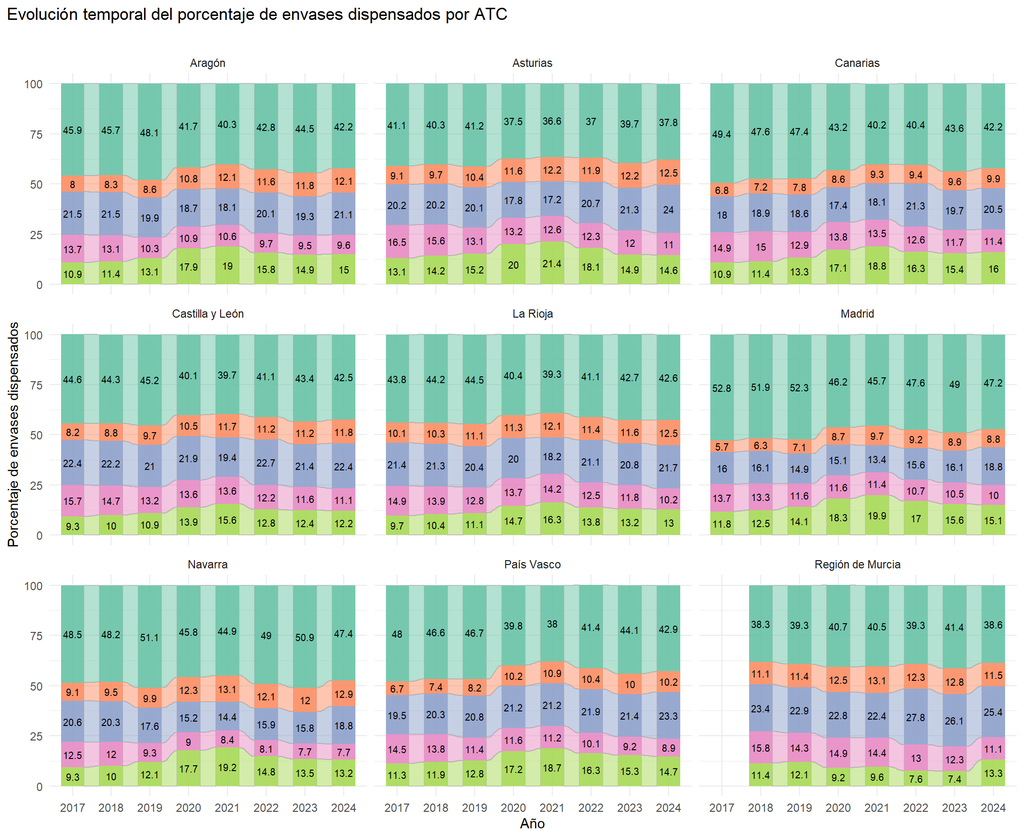

## Distribución de la población con alguna dispensación de antibióticos (*J01*) por grupo de edad y sexo

**Descripción figura**

Se muestra la distribución de la población con dispensaciones por grupo quinquenal de edad y sexo en toda la serie temporal.

Para la comunidad autónoma de Murcia la serie temporal es de 2018 a 2024.

Para el resto de comunidades es 2017-2024.

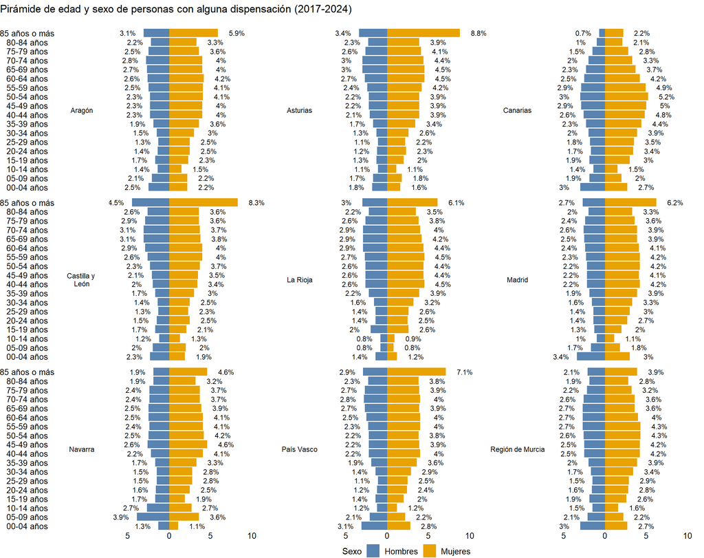

## Porcentaje de población con alguna dispensación de antibióticos (*J01*) en cada mes para el conjunto de la serie temporal y por sexo

**Descripción figura**

Se muestra la distribución de la población con dispensaciones por sexo y mes en toda la serie temporal. Se construye calculando el porcentaje de personas con alguna dispensación por sexo para cada mes de cada año y luego realizando la media de cada mes a lo largo de la serie temporal.

Para la comunidad autónoma de Murcia la serie temporal es de 2018 a 2024.

Para el resto de comunidades es 2017-2024.

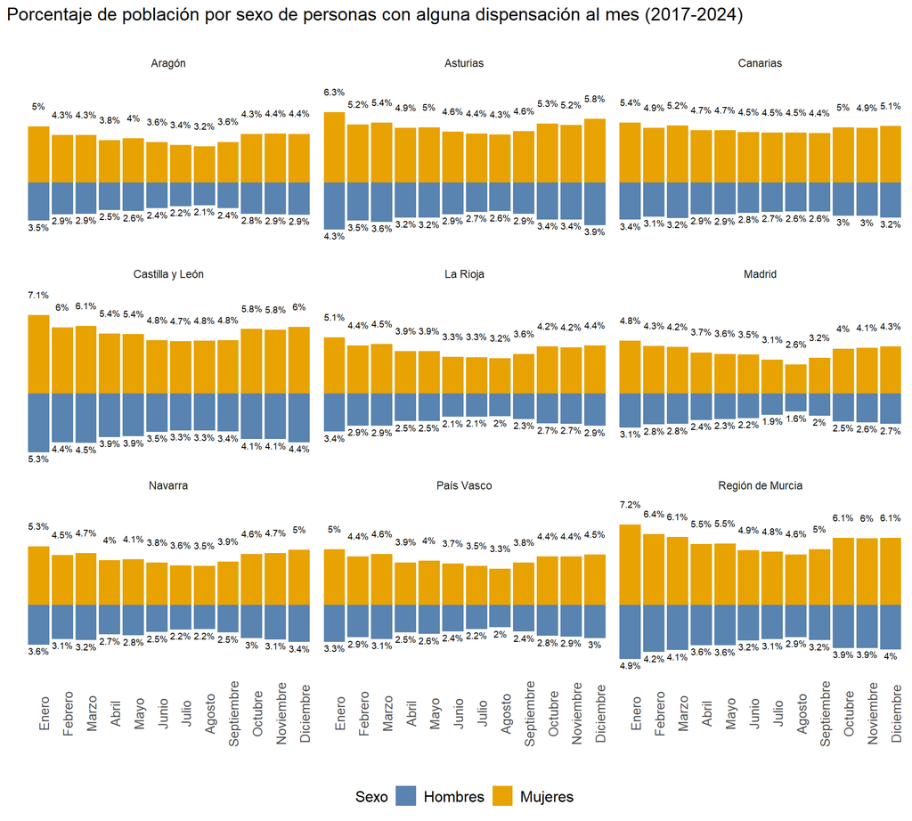

## Evolución de la variación de consumo por ZBS (SNS)

**Descripción figura**

Se muestra la variación (mediante violines) del consumo (DHD) en las zonas básicas de salud que componen el sistema nacional de salud de manera que cada punto es una zona básica. Las líneas discontinuas negras son la mediana (P50) anual y la línea discontinua roja (P50 global) es la mediana de toda la serie temporal.

**Antibióticos (J01)**

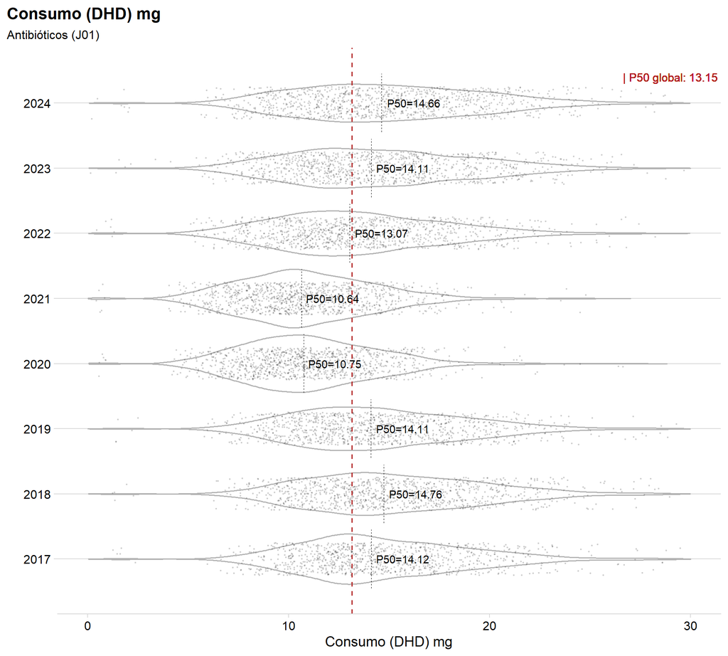

**Penicilinas (J01C)**

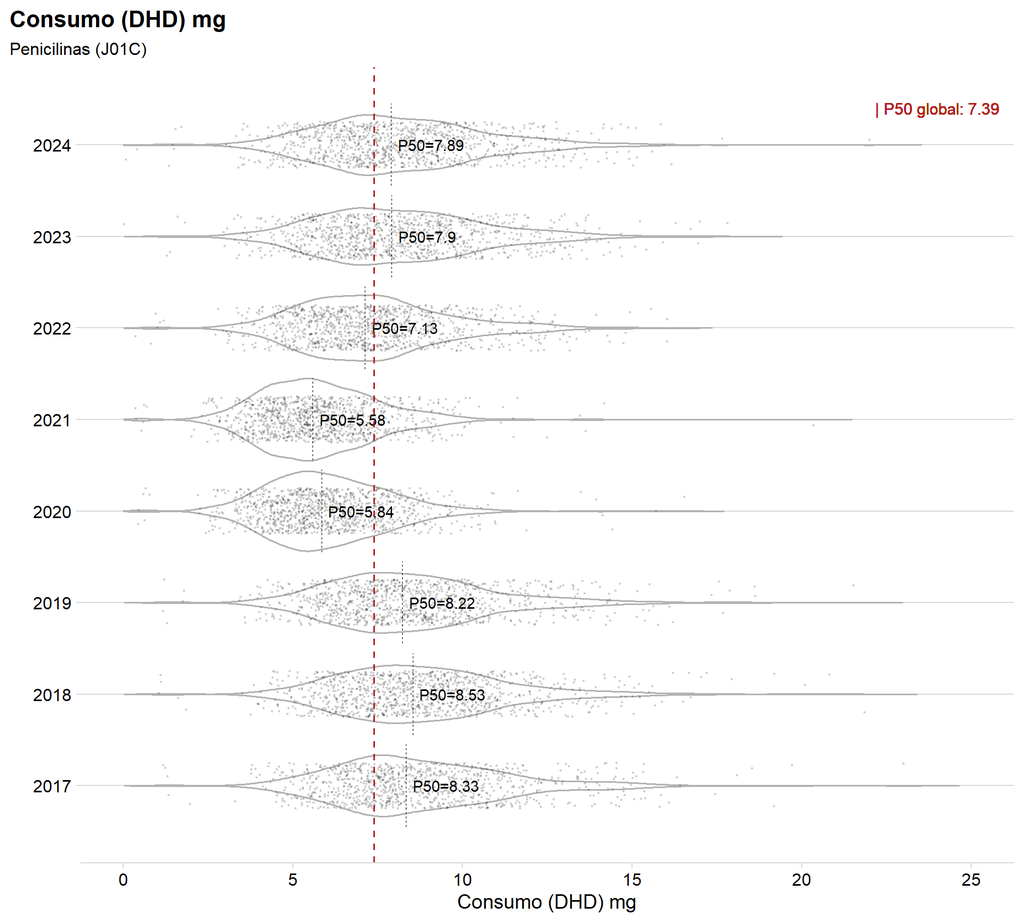

**Otros betalactámicos (J01D)**

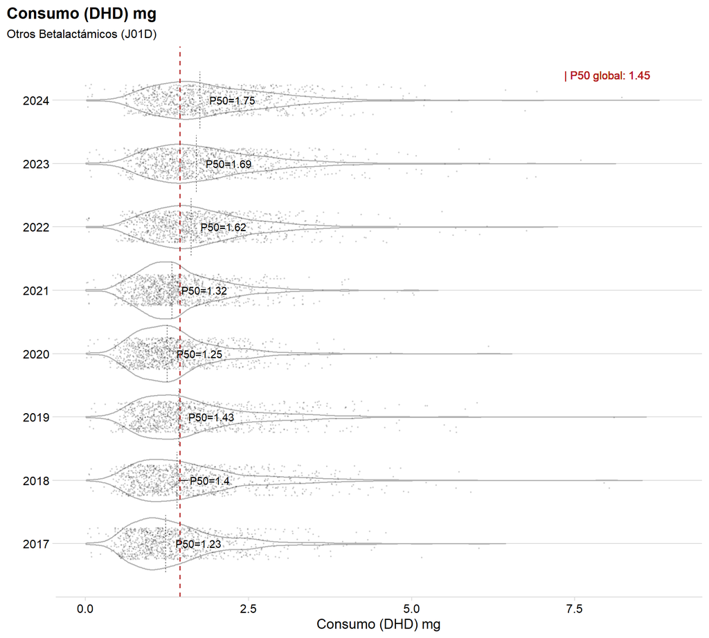

**Macrólidos, lincosaminas, estreptograminas (J01F)**

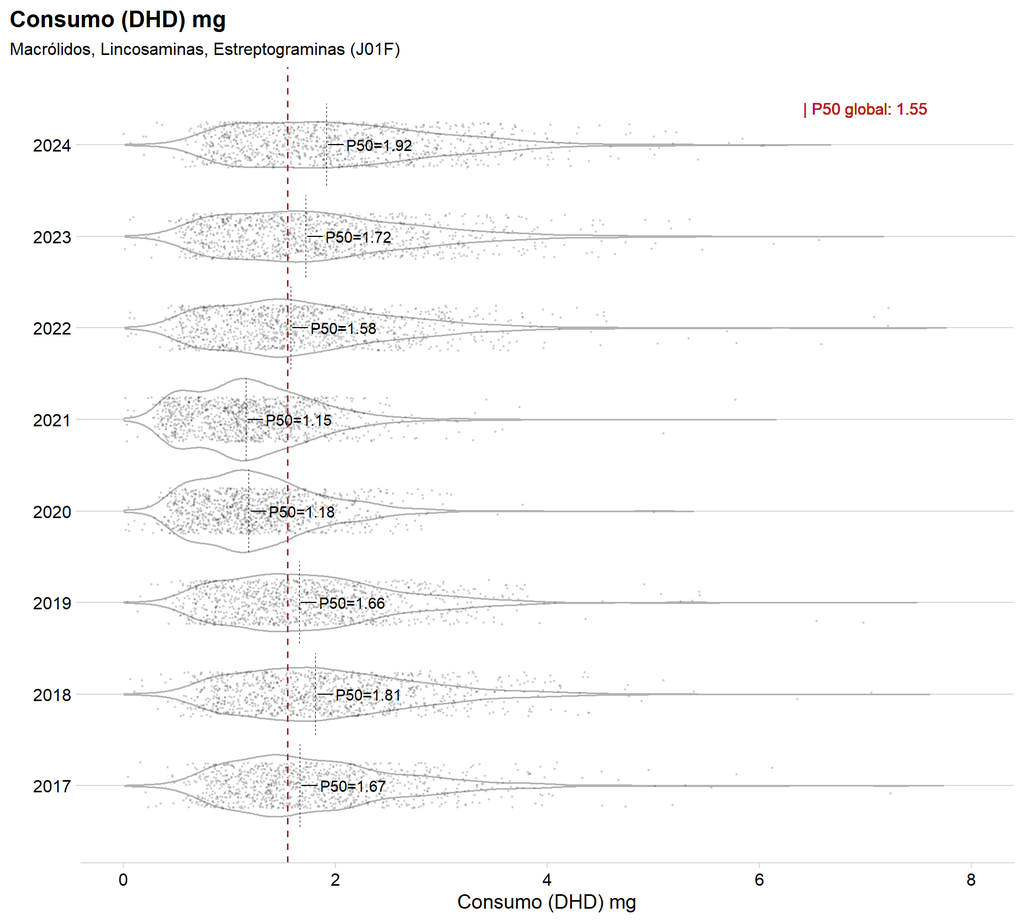

**Fluorquinolonas (J01MA)**

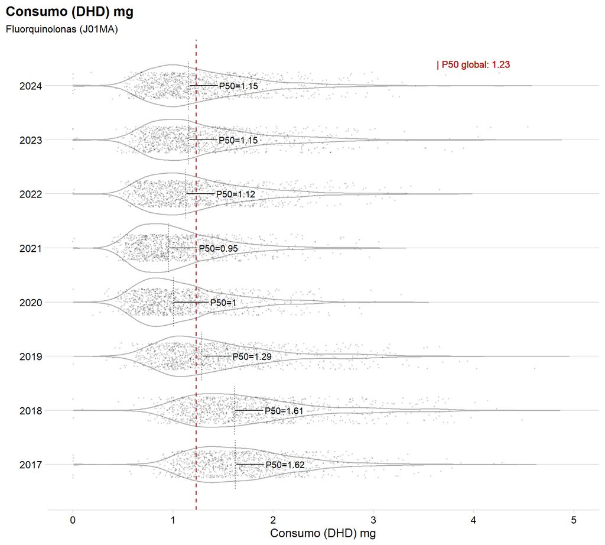

**Otros antibacterianos (J01X)**

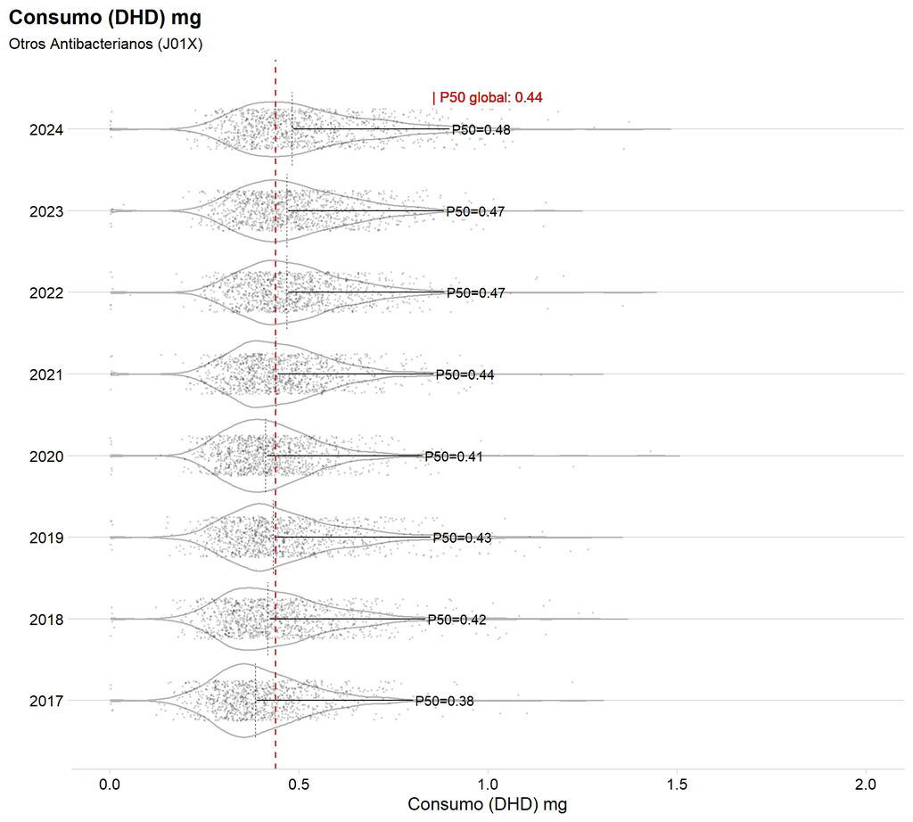

## Evolución de la variación de consumo por ZBS y TSI (SNS)

**Descripción figura**

Se muestra la variación (mediante violines) del consumo (DHD) en las zonas básicas de salud que componen el sistema nacional de salud de manera que cada punto es una zona básica. Las líneas discontinuas negras son la mediana (P50) anual y la línea discontinua roja (P50 global) es la mediana de toda la serie temporal. Se comparan: categorías TSI < 18.000 € vs categorías TSI >= 18.000 €.

**Antibióticos (J01)**

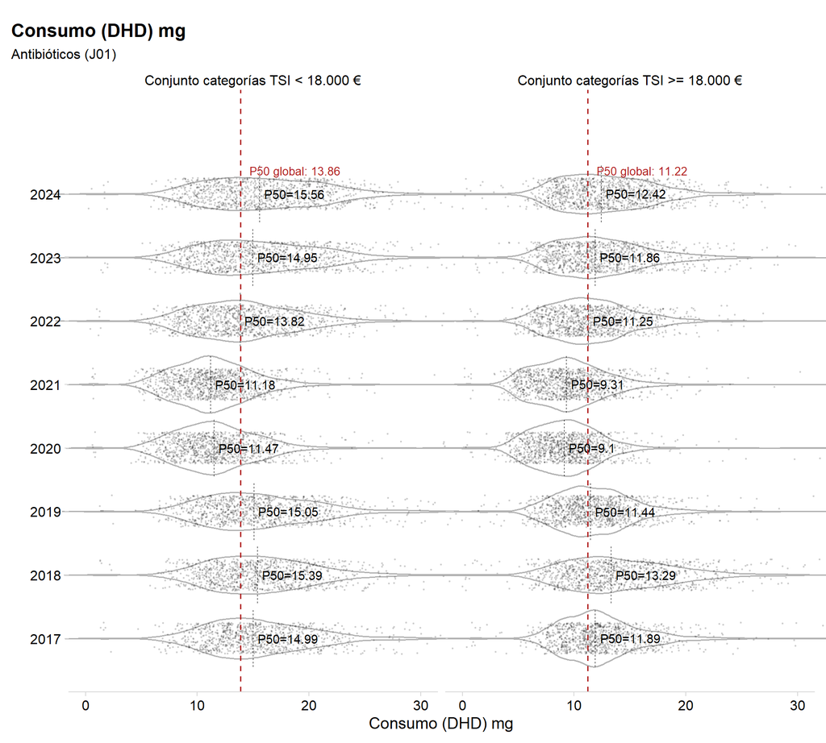

**Penicilinas (J01C)**

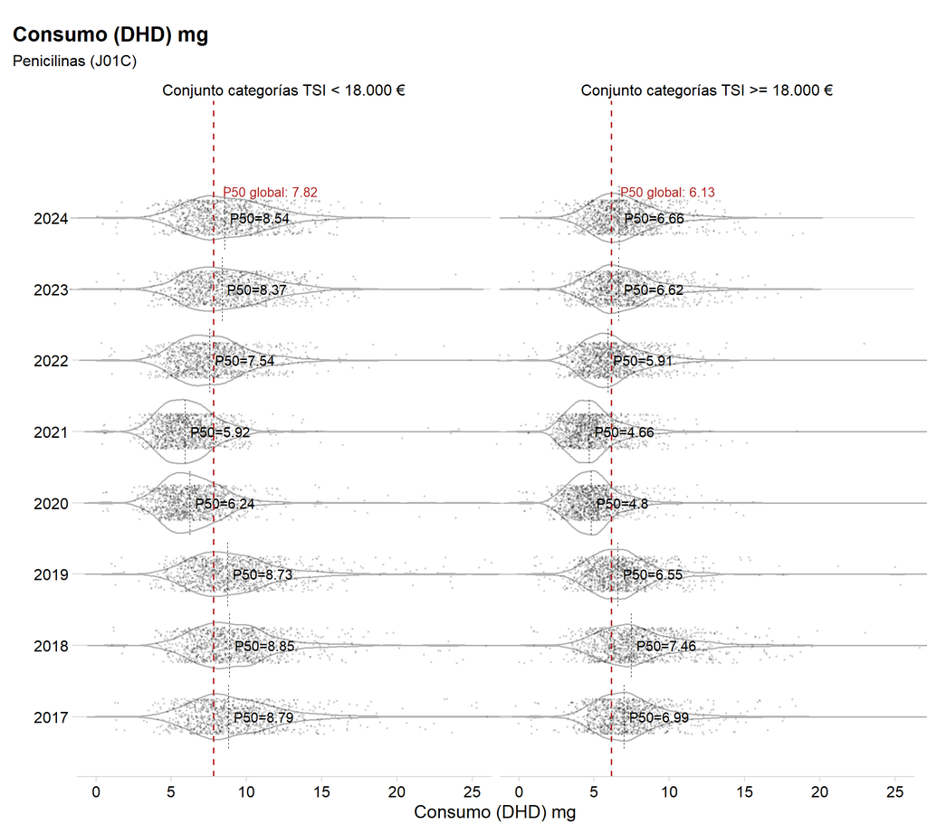

**Otros betalactámicos (J01D)**

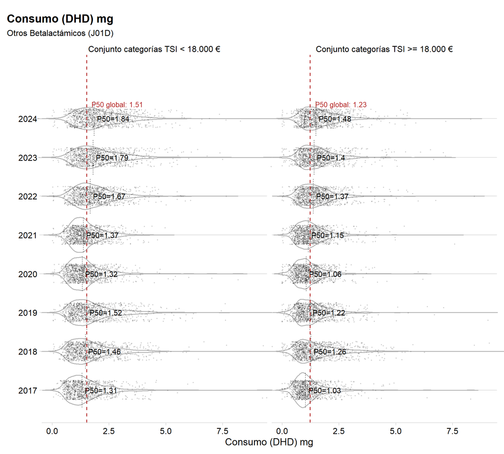

**Macrólidos, lincosaminas, estreptograminas (J01F)**

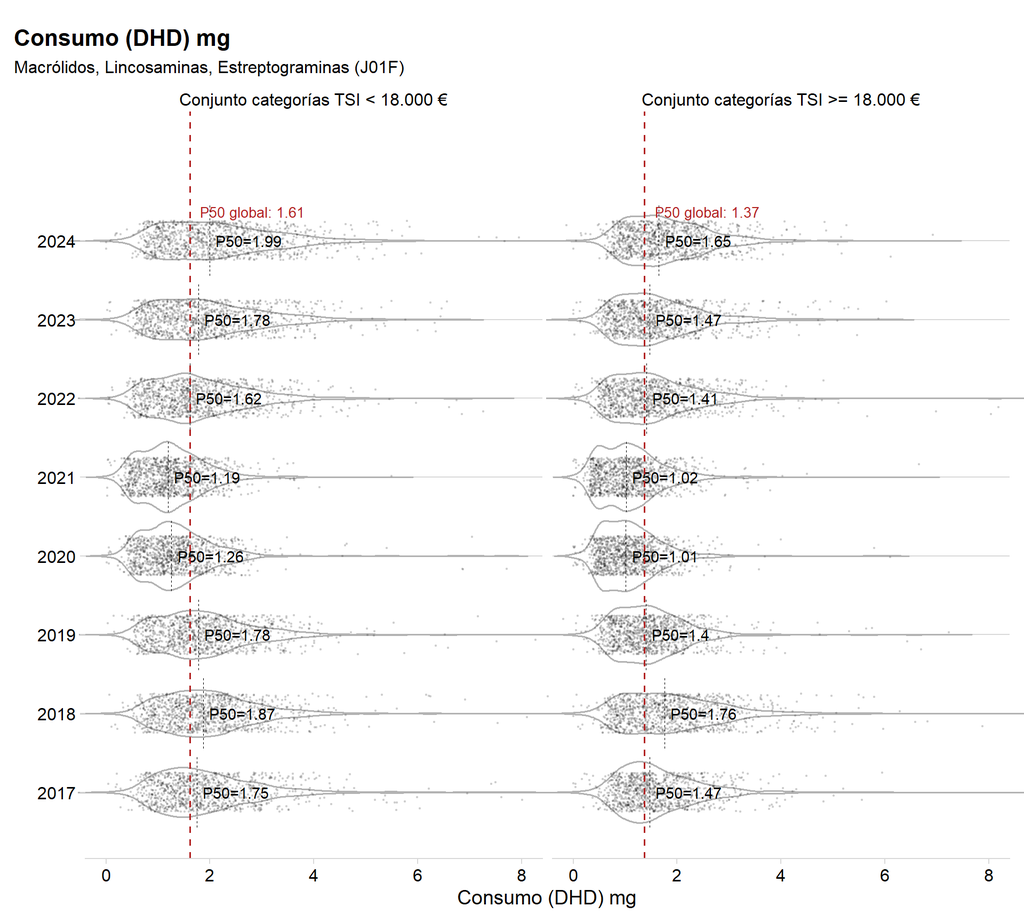

**Fluorquinolonas (J01MA)**

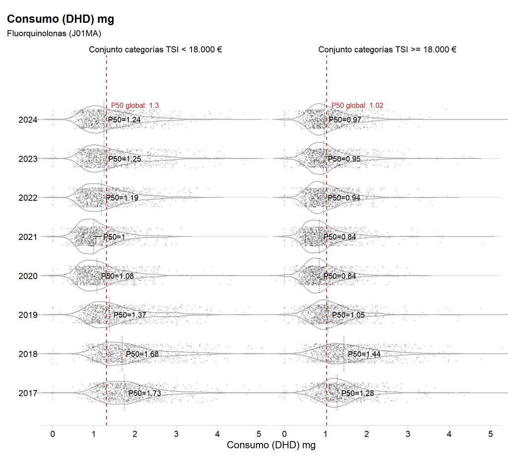

**Otros antibacterianos (J01X)**

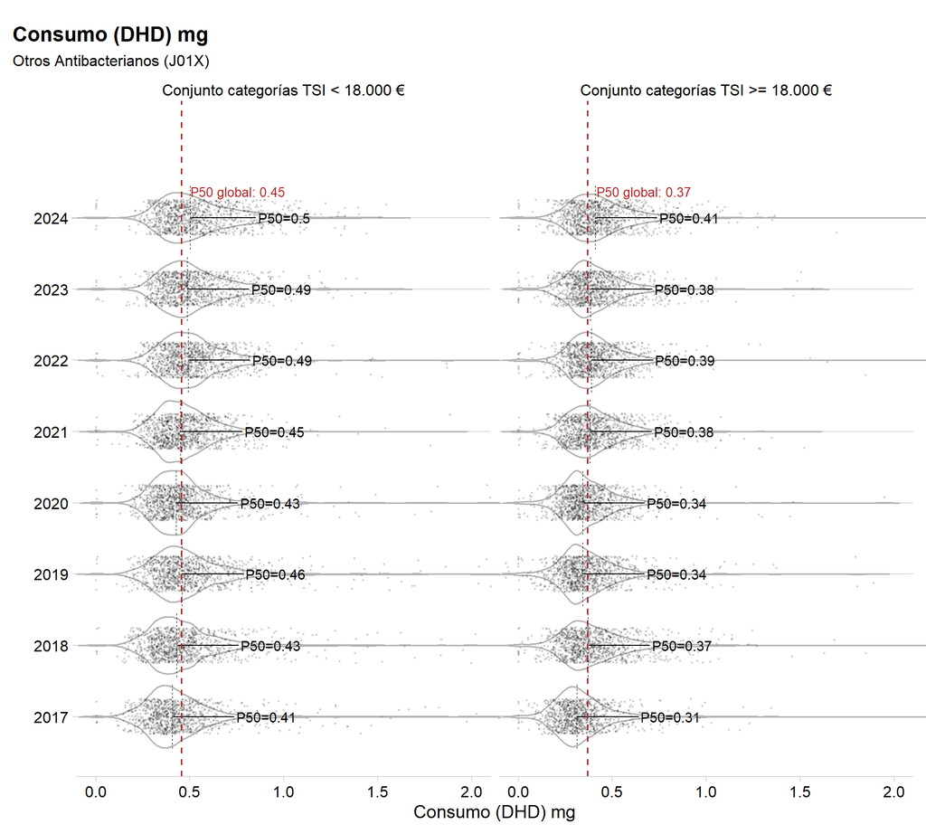

## Evolución de la variación de consumo (DHD) por ZBS y por CCAA

**Descripción figura**

Se muestra la evolución de la variación por CCAA del consumo (DHD) en las zonas básicas de salud que componen el sistema nacional de salud de manera que cada punto es una zona básica. La línea sólida roja es la mediana nacional y la zona sobreada gris es el rango intercuartílico, por lo que son comunes a todas las comunidades.

**Antibióticos (J01)**

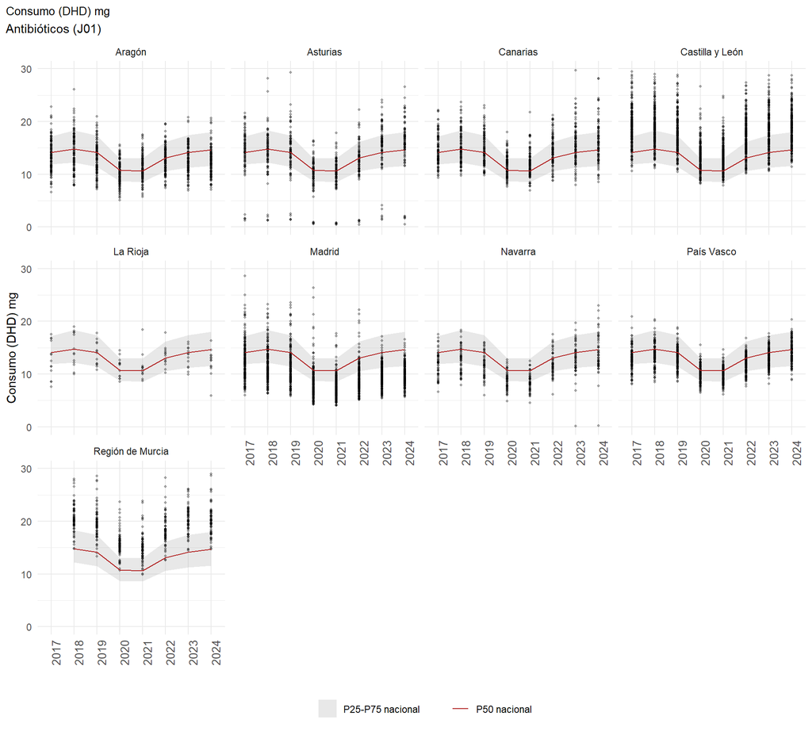

**Penicilinas (J01C)**

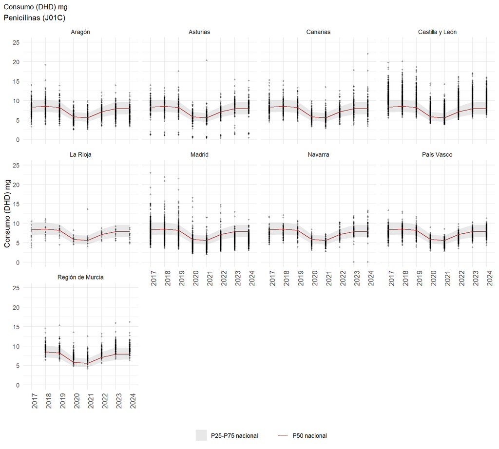

**Otros betalactámicos (J01D)**

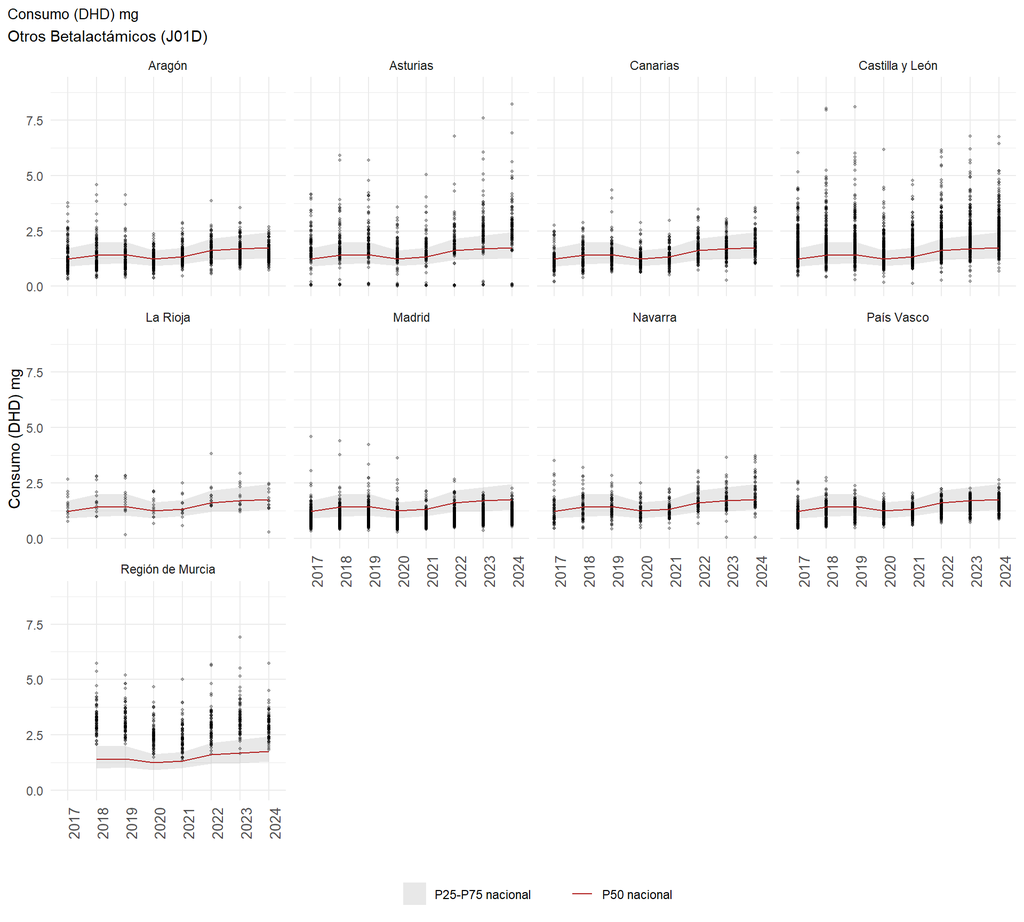

**Macrólidos, lincosaminas, estreptograminas (J01F)**

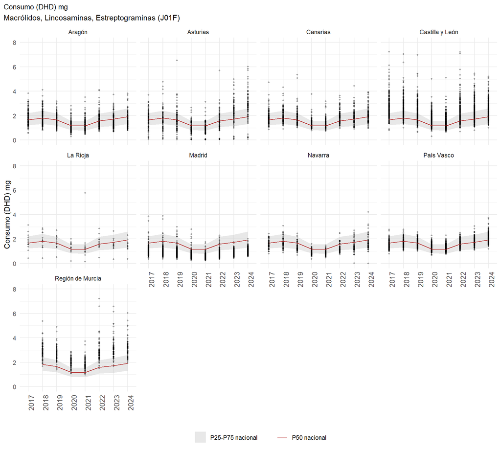

**Fluorquinolonas (J01MA)**

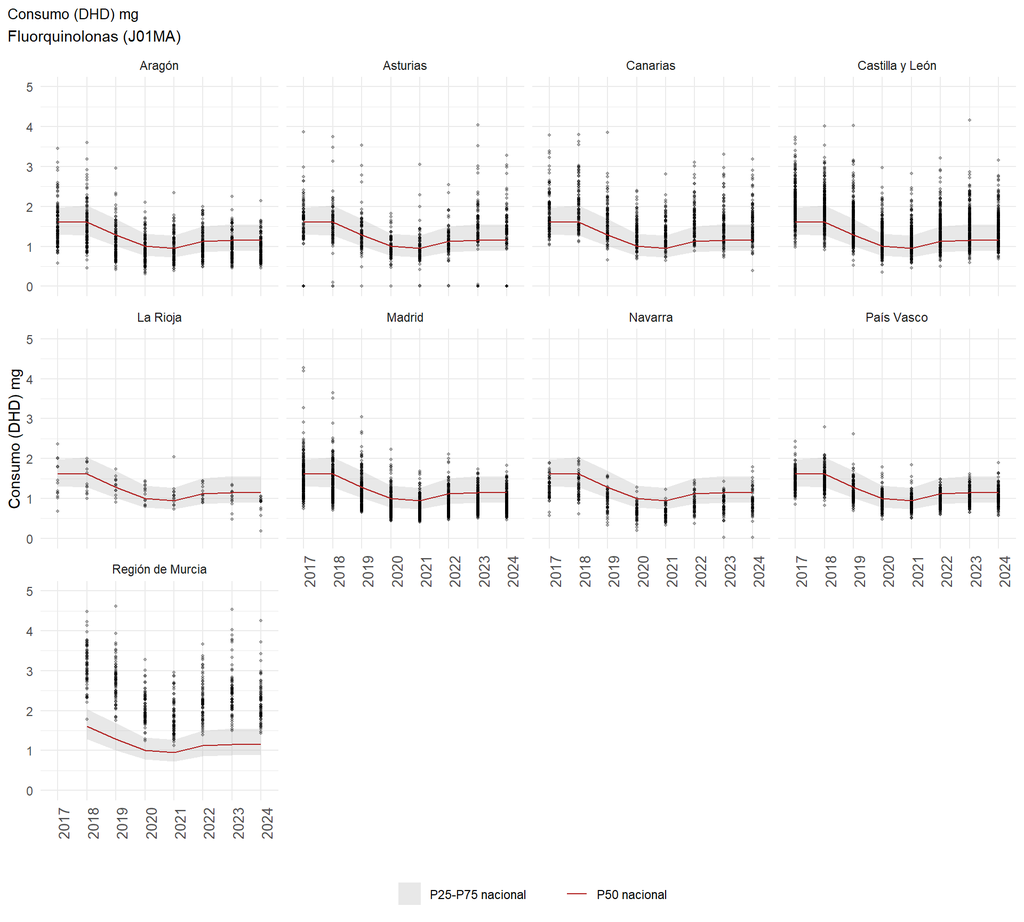

**Otros antibacterianos (J01X)**

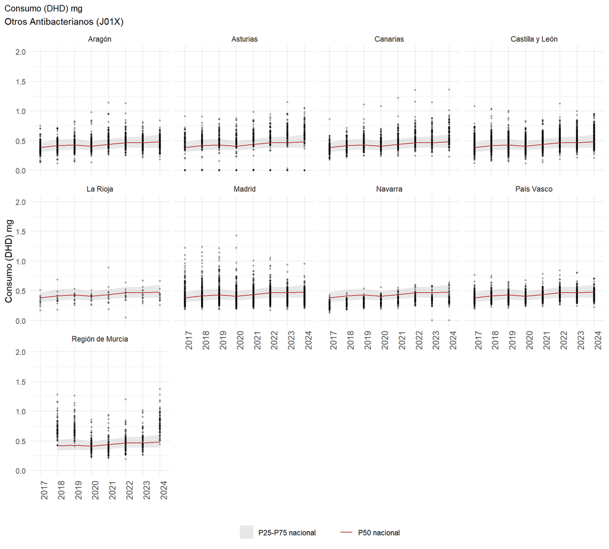

## Variación geográfica de consumo (DHD) de antibióticos en el año 2024

**Descripción figura**

Se muestra la variación geográfica mediante mapas por CCAA del consumo (DHD) en las zonas básicas de salud que componen el sistema nacional de salud para el último año disponible. La figura está coloreada por quintiles calculados a nivel nacional.

**Antibióticos (J01)**

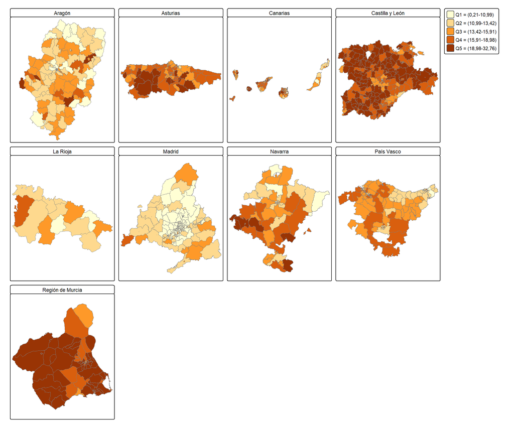

**Penicilinas (J01C)**

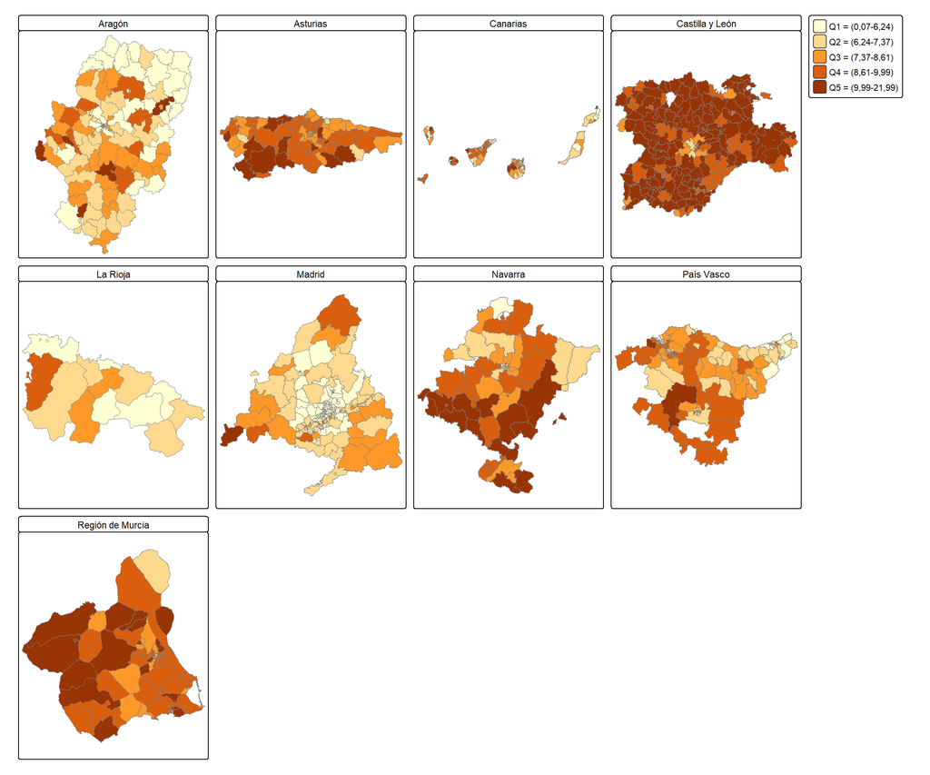

**Otros betalactámicos (J01D)**

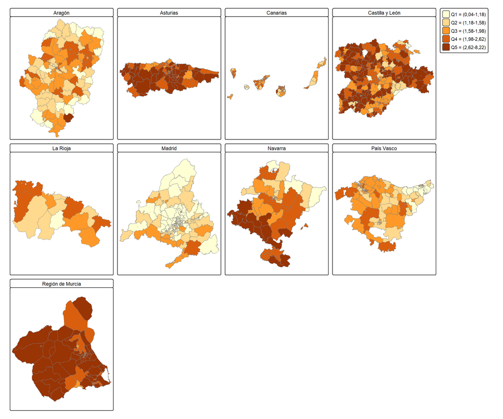

**Macrólidos, lincosaminas, estreptograminas (J01F)**

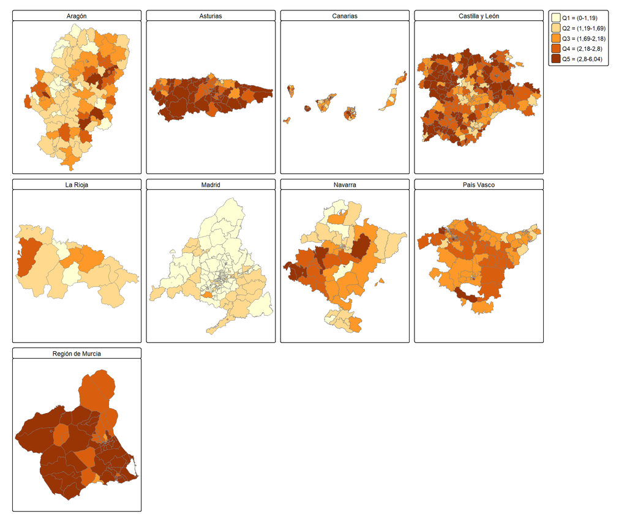

**Fluorquinolonas (J01MA)**

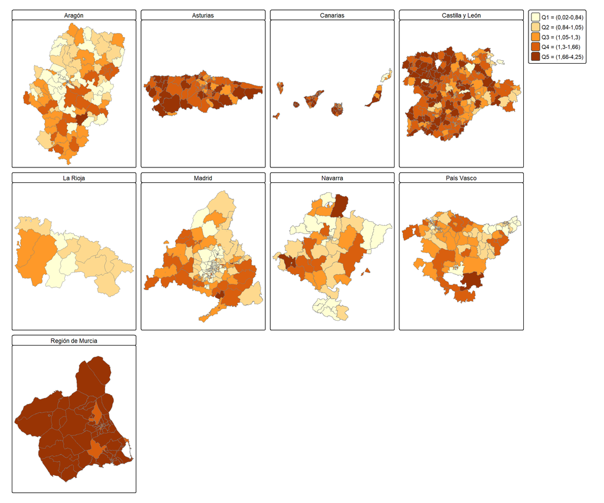

**Otros antibacterianos (J01X)**

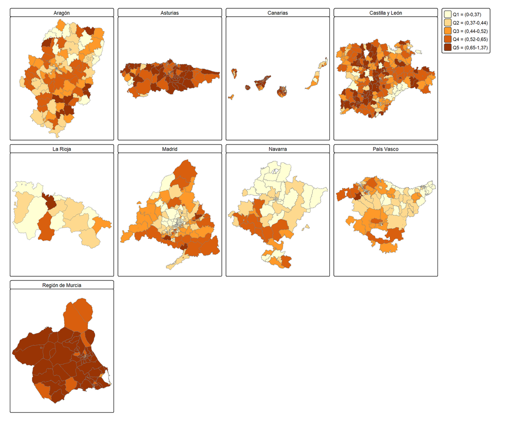

## Evolución de la variación por ZBS de los indicadores PROA

**Descripción figura**

Se muestra la evolución de la variación por CCAA del porcentaje de envases dispensados en las zonas básicas de salud que componen el sistema nacional de salud de manera que cada punto es una zona básica. La línea sólida roja es la mediana nacional y la zona sobreada gris es el rango intercuartílico, por lo que son comunes a todas las comunidades. Las ZBS están coloreadas en función de la lógica favorable de dispensación, siendo esta dependiente de cada fármaco (rojo - peor; negro - mejor).

**% Amoxicilina sin ácido clavulánico**

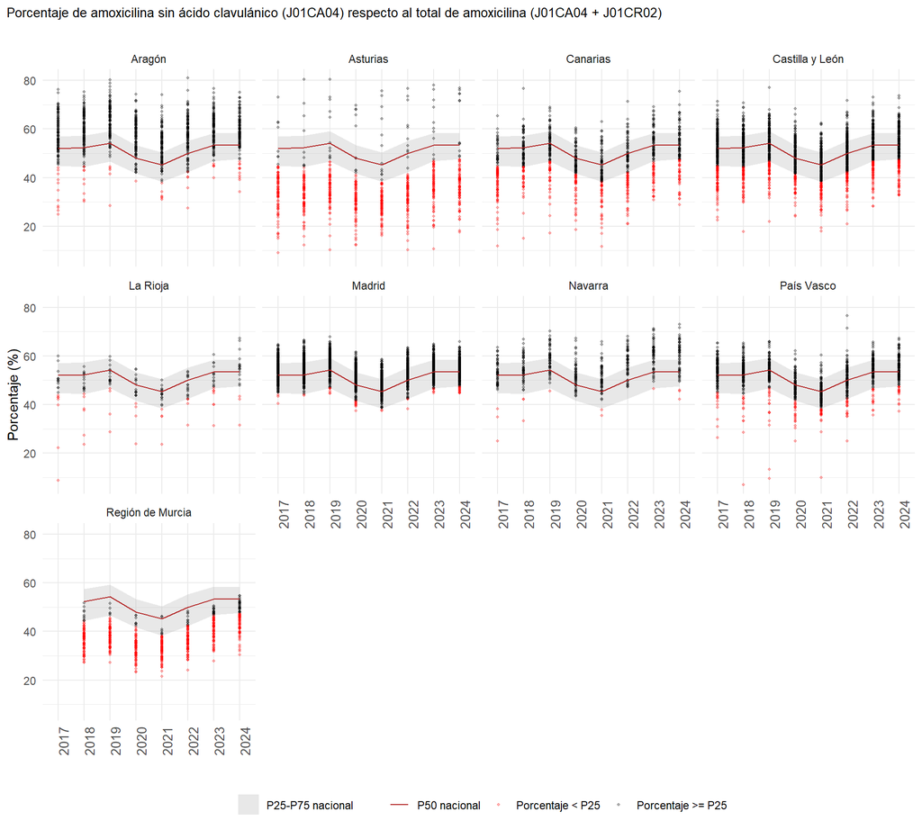

**% Antibiótico espectro reducido**

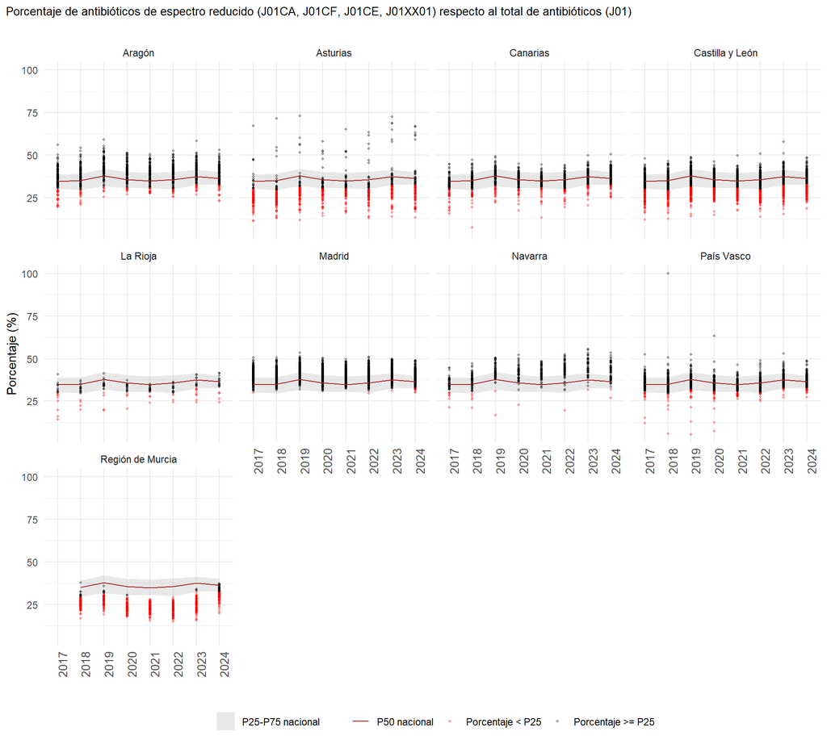

**% Penicilinas sens. betalactamasas**

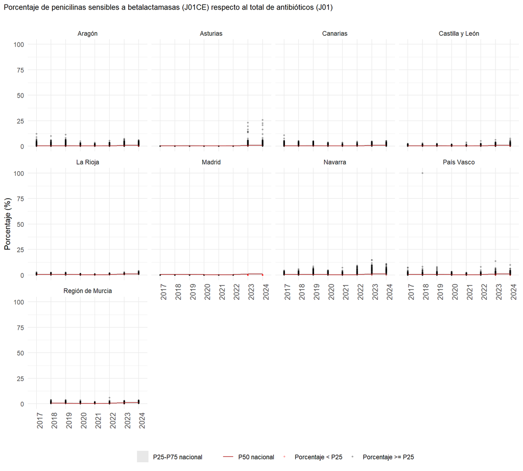